# Final Project

12/16/19

For my project I wanted to analyze what variables are cofounding with poverty in the United States. Specifically, I looked at the relationship between poverty and race.

## Front Matter

```r
# clean up workspace environment
rm(list = ls())

# all packages used for the assignment
library(mosaic)
library(tidyverse)
library(manipulate)
library(ggplot2)
library(readxl)
library(devtools)
library(leaflet)
library(usmap)
library(ggplot2)
library(dplyr)
library(party)
library(rgdal)
library(RColorBrewer)
```

## Gathering Data Set 1

```r
library(readxl)
fooddata <- read_excel("~/Desktop/fooddata1.xlsx")
head(fooddata)
```

| CensusTract | State | County | Urban | POP2010 | OHU2010 | GroupQuartersFlag | NUMGQTRS | PCTGQTRS | LILATracts_1And10 | LILATracts_halfAnd10 | LILATracts_1And20 | LILATracts_Vehicle | HUNVFlag | LowIncomeTracts | PovertyRate | MedianFamilyIncome | LA1and10 | LAhalfand10 | LA1and20 | LATracts_half | LATracts1 | LATracts10 | LATracts20 | LATractsVehicle_20 | LAPOP1_10 | LAPOP05_10 | LAPOP1_20 | LALOWI1_10 | LALOWI05_10 | … |
| --- | --- | --- | --- | --- | --- | --- | --- | --- | --- | --- | --- | --- | --- | --- | --- | --- | --- | --- | --- | --- | --- | --- | --- | --- | --- | --- | --- | --- | --- | --- |
| 01001020100 | Alabama | Autauga | 1 | 1912 | 693 | 0 | 0 | 0.0000000 | 0 | 0 | 0 | 0 | 0 | 0 | 10.0 | 74750 | 1 | 1 | 1 | 1 | 1 | 0 | 0 | 0 | 1357.4809 | 1732.225 | 1357.4809 | 322.0846 | 411.6908 | … |
| 01001020200 | Alabama | Autauga | 1 | 2170 | 743 | 0 | 181 | 0.0834101 | 0 | 0 | 0 | 0 | 0 | 0 | 18.2 | 51875 | 0 | 1 | 0 | 1 | 0 | 0 | 0 | 0 | 483.4297 | 1410.375 | 483.4297 | 145.1414 | 475.3060 | … |
| 01001020300 | Alabama | Autauga | 1 | 3373 | 1256 | 0 | 0 | 0.0000000 | 0 | 0 | 0 | 0 | 0 | 0 | 19.1 | 52905 | 1 | 1 | 1 | 1 | 1 | 0 | 0 | 0 | 1417.8749 | 2764.604 | 1417.8749 | 696.6368 | 1350.1765 | … |
| 01001020400 | Alabama | Autauga | 1 | 4386 | 1722 | 0 | 0 | 0.0000000 | 0 | 0 | 0 | 0 | 0 | 0 | 3.3 | 68079 | 1 | 1 | 1 | 1 | 1 | 0 | 0 | 0 | 1363.4669 | 3651.061 | 1363.4669 | 409.5878 | 1067.8445 | … |
| 01001020500 | Alabama | Autauga | 1 | 10766 | 4082 | 0 | 181 | 0.0168122 | 0 | 0 | 0 | 0 | 1 | 0 | 8.5 | 77819 | 1 | 1 | 1 | 1 | 1 | 0 | 0 | 1 | 2643.0952 | 7778.396 | 2643.0952 | 623.0766 | 1913.4536 | … |
| 01001020600 | Alabama | Autauga | 1 | 3668 | 1311 | 0 | 0 | 0.0000000 | 0 | 0 | 0 | 0 | 0 | 0 | 14.1 | 67218 | 1 | 1 | 1 | 1 | 1 | 0 | 0 | 0 | 2568.5455 | 3540.571 | 2568.5455 | 1090.7346 | 1455.4913 | … |

####This data set contains data on each town in the United States but names them by Census Tract rather than town name.

##Gathering Data Set 2

```r
mapdata<-
((usmap::us_map(regions="counties")))
head(mapdata)
```

|  | x | y | order | hole | piece | group | fips | abbr | full | county |
| --- | --- | --- | --- | --- | --- | --- | --- | --- | --- | --- |
| 1 | 1225889 | -1275020 | 1 | FALSE | 1 | 01001.1 | 01001 | AL | Alabama | Autauga County |
| 2 | 1244873 | -1272331 | 2 | FALSE | 1 | 01001.1 | 01001 | AL | Alabama | Autauga County |
| 3 | 1244129 | -1267515 | 3 | FALSE | 1 | 01001.1 | 01001 | AL | Alabama | Autauga County |
| 4 | 1272010 | -1262889 | 4 | FALSE | 1 | 01001.1 | 01001 | AL | Alabama | Autauga County |
| 5 | 1276797 | -1295514 | 5 | FALSE | 1 | 01001.1 | 01001 | AL | Alabama | Autauga County |
| 6 | 1272367 | -1296730 | 6 | FALSE | 1 | 01001.1 | 01001 | AL | Alabama | Autauga County |

####This data set also does not name the towns but it does contain the x and y coordinates for each of them.

## Cleaning Data Set 1

```r
#renaming and mutating
fooddata <-
  fooddata %>%
  filter(row_number() > 1)%>%
  rename(state = "State",
         county = "County",
         pop = 'POP2010',
         housingunits = 'OHU2010',
         lowinc = "TractLOWI",
    novehicle = 'TractHUNV',
         SNAP = 'TractSNAP')%>%
  mutate(novehicle=(novehicle/pop)*100, SNAP=(SNAP/pop)*100, lowinc=(lowinc/pop)*100, minoritypop=((TractBlack+TractAsian+TractNHOPI+TractAIAN+TractOMultir+TractHispanic)/pop)*100)

head(fooddata)
```

| CensusTract | state | county | Urban | pop | housingunits | GroupQuartersFlag | NUMGQTRS | PCTGQTRS | LILATracts_1And10 | LILATracts_halfAnd10 | LILATracts_1And20 | LILATracts_Vehicle | HUNVFlag | LowIncomeTracts | PovertyRate | MedianFamilyIncome | LA1and10 | LAhalfand10 | LA1and20 | LATracts_half | LATracts1 | LATracts10 | LATracts20 | LATractsVehicle_20 | LAPOP1_10 | LAPOP05_10 | LAPOP1_20 | LALOWI1_10 | LALOWI05_10 | … |
| --- | --- | --- | --- | --- | --- | --- | --- | --- | --- | --- | --- | --- | --- | --- | --- | --- | --- | --- | --- | --- | --- | --- | --- | --- | --- | --- | --- | --- | --- | --- |
| 01001020200 | Alabama | Autauga | 1 | 2170 | 743 | 0 | 181 | 0.0834101 | 0 | 0 | 0 | 0 | 0 | 0 | 18.2 | 51875 | 0 | 1 | 0 | 1 | 0 | 0 | 0 | 0 | 483.4297 | 1410.375 | 483.4297 | 145.1414 | 475.306 | … |
| 01001020300 | Alabama | Autauga | 1 | 3373 | 1256 | 0 | 0 | 0.0000000 | 0 | 0 | 0 | 0 | 0 | 0 | 19.1 | 52905 | 1 | 1 | 1 | 1 | 1 | 0 | 0 | 0 | 1417.8749 | 2764.604 | 1417.8749 | 696.6368 | 1350.177 | … |
| 01001020400 | Alabama | Autauga | 1 | 4386 | 1722 | 0 | 0 | 0.0000000 | 0 | 0 | 0 | 0 | 0 | 0 | 3.3 | 68079 | 1 | 1 | 1 | 1 | 1 | 0 | 0 | 0 | 1363.4669 | 3651.061 | 1363.4669 | 409.5878 | 1067.844 | … |
| 01001020500 | Alabama | Autauga | 1 | 10766 | 4082 | 0 | 181 | 0.0168122 | 0 | 0 | 0 | 0 | 1 | 0 | 8.5 | 77819 | 1 | 1 | 1 | 1 | 1 | 0 | 0 | 1 | 2643.0952 | 7778.396 | 2643.0952 | 623.0766 | 1913.454 | … |
| 01001020600 | Alabama | Autauga | 1 | 3668 | 1311 | 0 | 0 | 0.0000000 | 0 | 0 | 0 | 0 | 0 | 0 | 14.1 | 67218 | 1 | 1 | 1 | 1 | 1 | 0 | 0 | 0 | 2568.5455 | 3540.571 | 2568.5455 | 1090.7346 | 1455.491 | … |
| 01001020700 | Alabama | Autauga | 1 | 2891 | 1188 | 0 | 36 | 0.0124524 | 1 | 1 | 1 | 1 | 1 | 1 | 26.4 | 43646 | 1 | 1 | 1 | 1 | 1 | 0 | 0 | 1 | 1230.9799 | 2236.617 | 1230.9799 | 652.3856 | 1062.890 | … |

####Here I cleaned my data so that novehicle would be the percentage of the population without a vehicle. SNAP is the percentage of the population that are on food stamps. Lowinc is the percentage of the population that is considered low income. Minoritypop, one of my main focuses, is the percentage of the population that is not white.

##Cleaning Data Set 2

```r
regex <- ".*([County])$"
mapdata<-
mapdata %>%
  filter(grepl(pattern = regex, county)) %>%
  mutate(county = gsub(pattern = " County", replacement = "", county))%>%
  rename(state="full")
```

####Here I used regular expressions to clean the mapdata so that the county column in the fooddata dataset would be compatable.

##Joining

```r
joined<-
  fooddata%>%
  left_join(mapdata)
  head(joined)
```

| CensusTract | state | county | Urban | pop | housingunits | GroupQuartersFlag | NUMGQTRS | PCTGQTRS | LILATracts_1And10 | LILATracts_halfAnd10 | LILATracts_1And20 | LILATracts_Vehicle | HUNVFlag | LowIncomeTracts | PovertyRate | MedianFamilyIncome | LA1and10 | LAhalfand10 | LA1and20 | LATracts_half | LATracts1 | LATracts10 | LATracts20 | LATractsVehicle_20 | LAPOP1_10 | LAPOP05_10 | LAPOP1_20 | LALOWI1_10 | LALOWI05_10 | … |
| --- | --- | --- | --- | --- | --- | --- | --- | --- | --- | --- | --- | --- | --- | --- | --- | --- | --- | --- | --- | --- | --- | --- | --- | --- | --- | --- | --- | --- | --- | --- |
| 01001020200 | Alabama | Autauga | 1 | 2170 | 743 | 0 | 181 | 0.0834101 | 0 | 0 | 0 | 0 | 0 | 0 | 18.2 | 51875 | 0 | 1 | 0 | 1 | 0 | 0 | 0 | 0 | 483.4297 | 1410.375 | 483.4297 | 145.1414 | 475.306 | … |
| 01001020200 | Alabama | Autauga | 1 | 2170 | 743 | 0 | 181 | 0.0834101 | 0 | 0 | 0 | 0 | 0 | 0 | 18.2 | 51875 | 0 | 1 | 0 | 1 | 0 | 0 | 0 | 0 | 483.4297 | 1410.375 | 483.4297 | 145.1414 | 475.306 | … |
| 01001020200 | Alabama | Autauga | 1 | 2170 | 743 | 0 | 181 | 0.0834101 | 0 | 0 | 0 | 0 | 0 | 0 | 18.2 | 51875 | 0 | 1 | 0 | 1 | 0 | 0 | 0 | 0 | 483.4297 | 1410.375 | 483.4297 | 145.1414 | 475.306 | … |
| 01001020200 | Alabama | Autauga | 1 | 2170 | 743 | 0 | 181 | 0.0834101 | 0 | 0 | 0 | 0 | 0 | 0 | 18.2 | 51875 | 0 | 1 | 0 | 1 | 0 | 0 | 0 | 0 | 483.4297 | 1410.375 | 483.4297 | 145.1414 | 475.306 | … |
| 01001020200 | Alabama | Autauga | 1 | 2170 | 743 | 0 | 181 | 0.0834101 | 0 | 0 | 0 | 0 | 0 | 0 | 18.2 | 51875 | 0 | 1 | 0 | 1 | 0 | 0 | 0 | 0 | 483.4297 | 1410.375 | 483.4297 | 145.1414 | 475.306 | … |
| 01001020200 | Alabama | Autauga | 1 | 2170 | 743 | 0 | 181 | 0.0834101 | 0 | 0 | 0 | 0 | 0 | 0 | 18.2 | 51875 | 0 | 1 | 0 | 1 | 0 | 0 | 0 | 0 | 483.4297 | 1410.375 | 483.4297 | 145.1414 | 475.306 | … |

####Here I joined my datasets.

##Graphing

[figure not shown]

```r
#GRAPH1

probability1<-
  fooddata%>%
  na.omit()

mod1<- party::ctree(PovertyRate~Urban+minoritypop, data=fooddata)
plot(mod1, type="simple")
```

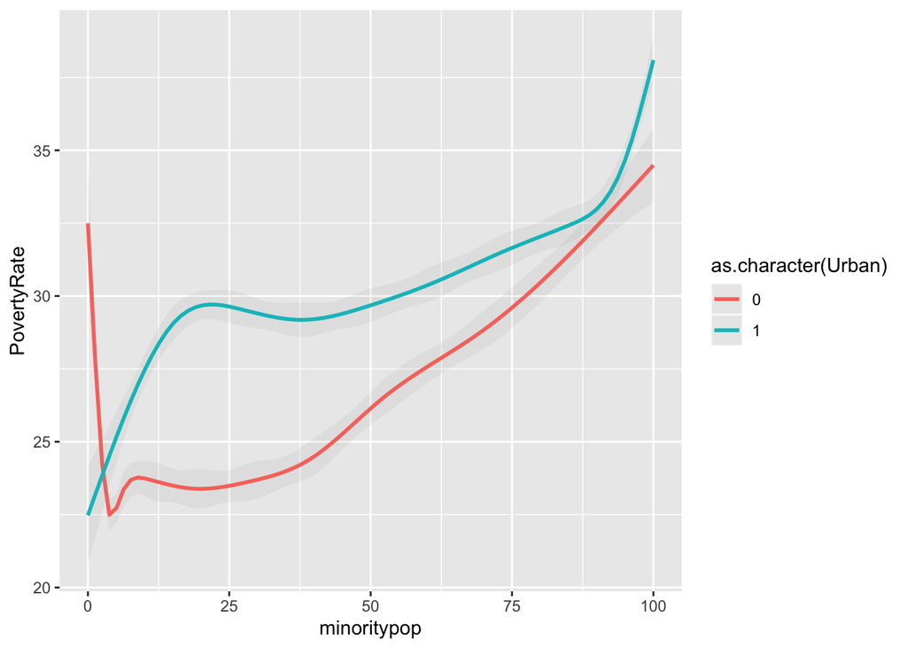

```r
#GRAPH2
fooddata %>%
  group_by(county) %>%
  filter(PovertyRate > 18)%>%
  ggplot(aes(x=minoritypop, y=PovertyRate, color=as.character(Urban))) +
 geom_smooth(alpha=.1) +
  xlim(0,100)
```

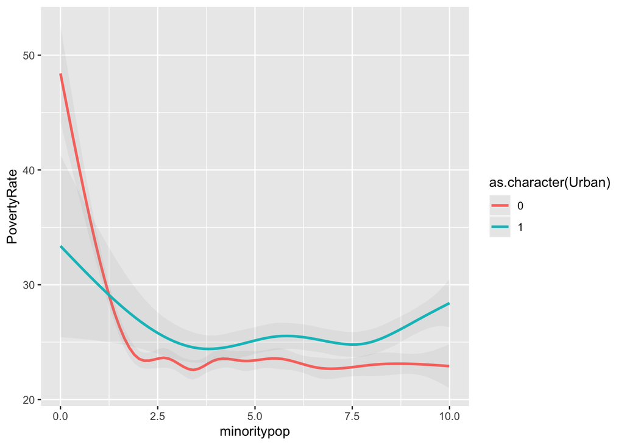

```r
#GRAPH3
fooddata %>%
  group_by(county) %>%
  filter(PovertyRate > 18)%>%
  ggplot(aes(x=minoritypop, y=PovertyRate, color=as.character(Urban))) +
 geom_smooth(alpha=.1) +
  xlim(0,10)
```

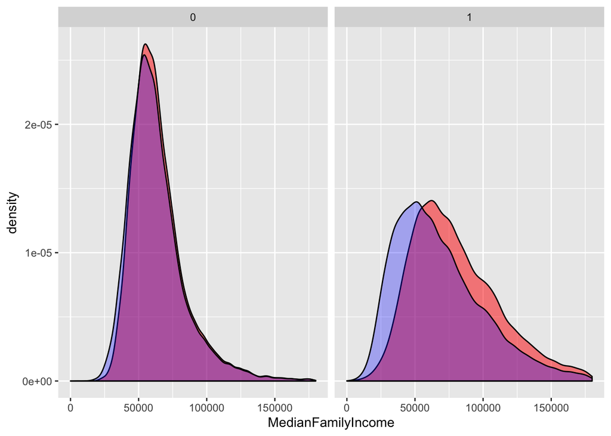

```r
#GRAPH4
fooddata %>%
  group_by(county) %>%
  filter(minoritypop<50)%>%
  ggplot(aes(x=MedianFamilyIncome)) +
  geom_density(fill="red", alpha=.5)+
  geom_density(data=fooddata, fill="blue", alpha=.30)+
  facet_wrap(~Urban)+
  xlim(10,180000)
```

####This is a graph of median family income. The blue curve is the national average, this data includes all towns, regardless of the percentage of the population that is minority. The red curve is towns that are predominantly white. What I find interesting about this curve is that for non-urban areas, there is not a large difference between median income for predominantly white areas and all areas. However, in urban settings (marked by “1”), there is a difference in the peaks for predominantly white areas and the average. It should also be noted that the urban areas have a more noticeable right skew, while the non-urban areas are more bell shaped.

```r
map<-
  joined%>%
ggplot()+
  map(data=joined, aes(x= x, y= y, group=group), .f="") +
  geom_polygon(aes(fill=PovertyRate))
```